# Data Analysis Project

Sandra Smith, Lauren Bentley, Katelynn Winebrenner

## Introduction, Preliminary Analysis and Definitions

In this notebook, we are analyzing Maryland precinct data from the 2020 and 2024 elections. To do this, we have loaded in 2 data sets from the Maryland State Board of Elections.

The 2020 data set has 23 columns and 95283 rows. The 2024 data set has 21 columns and 117875 rows. Both data sets show each precinct, information about the precinct, each race, each candidate, the winner, how many votes each candidate received and method of vote.

Because each year has different candidates and different races, we should identify which races happened both years and in all counties in order to make a clear analysis. We should also identify clear candidates in each race so that we aren’t analyzing someone who is listed, but received one write in vote, for example.

To meet these parameters, we will focus on the race for president because it happened both years and in every precinct. In terms of candidates, we will focus on Donald Trump and Joe Biden for 2020 and Kamala Harris and Donald Trump for 2024.

We should be able to answer most of our questions with this data. However, we will need to load in data from the census in order to answer questions about economic status and identify. I don’t know how easy that will be to do by precinct, but we’ll see. We’ll also need to include information about eligible voters and registered voters to determine turnout.

## Load and Clean Data

```r
# Load required data
#setwd("~/Documents/GitHub/data_journalism_2025_spring/data_analysis")

uncleaned_precincts2020 <- read_csv("data/All_By_Precinct_2020_General.csv")
uncleaned_precincts2024 <- read_csv("data/PG24_AllPrecincts.csv")
```

```r
# Clean 2020, column names to match, county names, combine column district and column precinct, select columns
precincts2020 <- uncleaned_precincts2020 |>
  clean_names() |>
  mutate(county_name = case_when(
    county == "01" ~ "Allegany County",
    county == "02" ~ "Anne Arundel County",
    county == "03" ~ "Baltimore City",
    county == "04" ~ "Baltimore County",
    county == "05" ~ "Calvert County",
    county == "06" ~ "Caroline County",
    county == "07" ~ "Carroll County",
    county == "08" ~ "Cecil City",
    county == "09" ~ "Charles County",
    county == "10" ~ "Dorchester County",
    county == "11" ~ "Frederick County",
    county == "12" ~ "Garrett County",
    county == "13" ~ "Harford County",
    county == "14" ~ "Howard County",
    county == "15" ~ "Kent County",
    county == "16" ~ "Montgomery County",
    county == "17" ~ "Prince George's County",
    county == "18" ~ "Queen Anne's City",
    county == "19" ~ "Saint Mary's County",
    county == "20" ~ "Somerset County",
    county == "21" ~ "Talbot County",
    county == "22" ~ "Washington County",
    county == "23" ~ "Wicomico County",
    county == "24" ~ "Worcester County"
  ))|>
  mutate(election_district_precinct = str_c(election_district, election_precinct, sep = "-"),
         year = 2020)|> #chatgpt, str_c function to combine two column outputs by - in single column
  rename(
    election_day = election_day_votes,
    early= early_voting_votes,
    mail_in_1= by_mail_votes,
    mail_in_2 = by_mail_2_votes,
    provisional= prov_votes,
    total= total_votes,
    candidate_name = candidate_name,
    party = party
         )|>
      select(year,county, county_name, election_district_precinct, office_name, candidate_name, party, election_day, early, mail_in_1, mail_in_2, provisional, total)|>
  filter(
    office_name == "President - Vice Pres",
    candidate_name %in% c("Joe Biden", "Donald J. Trump")) #%n% from chatgpt
```

```r
# Clean 2024, column names to match, create total votes, select columns
precincts2024 <- uncleaned_precincts2024|>
  clean_names()|>
   rename(
     election_day = election_night_votes,
     mail_in_1 = mail_in_ballot_1_votes,
     mail_in_2 = mail_in_ballot_2_votes,
     early = early_votes,
     provisional= provisional_votes,
     candidate_name = candidate_name,
     party = party
     )|>
  mutate(
    total = (election_day + mail_in_1 + mail_in_2 + early + provisional),
    year = 2024
  )|>

    select(year, county, county_name, election_district_precinct, office_name, candidate_name, party, election_day, early, mail_in_1, mail_in_2, provisional, total)|>
 filter(
    office_name == "President - Vice Pres",
    candidate_name %in% c("Kamala D. Harris and Tim Walz", "Donald J. Trump and JD Vance") #%n% from chatgpt
  )
```

```r
# combine dataframes, not joining, but placing them on top of one another
precincts_combined <- bind_rows(precincts2020, precincts2024)
```

## Questions to answer

In this notebook, we are answering five questions about the data.

### Question 1

- **Question**: Which precincts experienced the most significant change in party support?
- **Analysis summary**: To find out which precincts experienced the most significant change in party support, we filtered each dataset with 2020 and 2024 precincts to show only the precinct, county and party. Then, we joined the datasets together and calculated the democratic and republican percent changes for each. Through this analysis, we found that Baltimore County 009-029 had the largest republican percent change from 2020 to 2024 and Baltimore County 009-027 also had the largest democratic percent change from 2020 to 2024. Washington County and Harford County precincts also had large percent change in party support. Prince George’s County 019-005 had the lowest democratic percent change and Washington County 013-002 had the lowest republican percent change.

```r
#Summarize votes by party (2020)
votes_2020 <- precincts_combined |>
  filter(year == 2020) |>
  group_by(election_district_precinct, county_name, party) |>
  summarize(total_votes_2020 = sum(total,na.rm = TRUE), .groups= "drop")

#Summarize votes by party (2024)
votes_2024 <- precincts_combined |>
  filter(year == 2024) |>
  group_by(election_district_precinct, county_name, party) |>
  summarize(total_votes_2024 = sum(total, na.rm=TRUE), .groups="drop")

#Join 2020 and 2024 datasets by party and precinct
vote_changes <- left_join(votes_2020, votes_2024, by = c("election_district_precinct", "county_name", "party"))

#Democrat percent change
democratic_changes <- vote_changes |>
  filter(party == "DEM") |>
  mutate(
    percent_change = ((total_votes_2024 - total_votes_2020) / total_votes_2020) * 100
  ) |>
  select(election_district_precinct, county_name, percent_change) |>
  arrange(desc(percent_change))

#Republican percent change
republican_changes <- vote_changes |>
  filter(party == "REP") |>
  mutate(
    percent_change = ((total_votes_2024 - total_votes_2020) / total_votes_2020) * 100
  ) |>
  select(election_district_precinct, county_name, percent_change) |>
  arrange(desc(percent_change))
```

### Question 2

- **Question**: How did voter turnout vary across precincts? What factors contributed to this?
- **Analysis summary**: To find how voter turnout varied across precincts from 2020 to 2024, we calculated the total number of votes by precinct for each year. We then seperated these datasets by year and joined them by precinct. We then calculated the percent changes for both increasing and decreasing votes. From this, we only looked at the top 10 precincts from each election district. We found that Prince George’s County and Washington County had the largest decrease in voter turnout from 2020 to 2024. Prince George’s County had small numbers within the dataset, with only 3 voters shown – so this number is not reflective of the other precinct changes. Harford County had the largest increase in voter turnout, along with various precincts in Baltimore County.

```r
#Total votes by precinct (2020 and 2024)
voter_turnout_summary <- precincts_combined |>
  group_by(year, election_district_precinct, county_name) |>
  summarize(total_voter_turnout = sum(total,na.rm=TRUE), .groups="drop")

#Seperate by year
voter_turnout_2020 <- voter_turnout_summary |>
  filter(year == 2020) |>
  select(election_district_precinct, county_name, total_turnout_2020 = total_voter_turnout)

voter_turnout_2024 <- voter_turnout_summary |>
  filter(year == 2024) |>
  select(election_district_precinct, county_name, total_turnout_2024 = total_voter_turnout)

#Join by precinct
voter_turnout_changes <- left_join(voter_turnout_2020,voter_turnout_2024, by = c("election_district_precinct", "county_name")) |>
  mutate(change = total_turnout_2024 - total_turnout_2020,
         percent_change= (change/total_turnout_2020) * 100)

#View largest increase and decrease
top_voter_increases <- voter_turnout_changes |>
  arrange(desc(percent_change)) |>
  slice_head(n=10)

top_voter_decreases <- voter_turnout_changes |>
  arrange(percent_change) |>
  slice_head(n=10)
```

### Question 3

- **Question**: How did early voting and mail-in ballots influence precinct-level results?
- **Analysis summary**: In order to figure out how mail-in ballots and early voting influence precinct-level results, I filtered the data by year and then summarized it, grouping by precinct, county name, party, early, provisional, and total amount of votes. I did this for both 2020 and 2024, then I calculated the percentage difference for early, mail-in, and provisional votes. Next, I changed the format in order to properly plot it and used ggplot to make a bar chart demonstrating the difference in mail-in and early votes based on party and year. You can see from the chart that Democrats make up a significantly higher number of mail-in votes, with the percentage in 2020 being nearly 60%. Republicans, on the other hand, make up a higher percentage of early votes. Ultimately, voting methods are somewhat split between party, meaning that precinct-level elections for these years would’ve received a higher number of main-ins from Democrats and a higher number of early votes from Republicans.

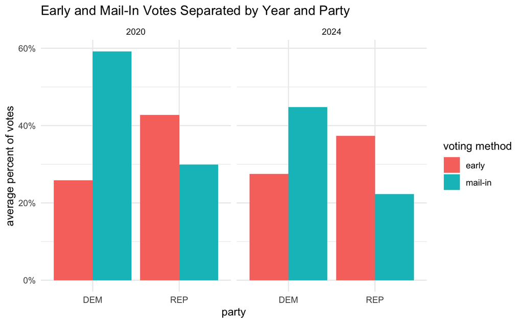

```r
#summarize votes by method in 2020
methods_2020 <- precincts_combined |>
  filter(year == 2020) |>
  group_by(
    election_district_precinct, county_name, party, early, mail_in_1, mail_in_2, provisional, total
  ) |>
    summarize(
      total_votes_20 = sum(total,na.rm = TRUE),
      .groups = "drop"
    ) |>
  mutate(year=2020)


#summarize votes by method in 2024
methods_2024 <- precincts_combined |>
  group_by(
    election_district_precinct, county_name, party, early, mail_in_1, mail_in_2, provisional, total
  ) |>
  summarize(
    total_votes_24 = sum(total,na.rm = TRUE),
    .groups = "drop"
    ) |>
  mutate(year=2024)

methods_combined <- bind_rows (methods_2020, methods_2024)


#calculate percentage difference
methods_combined <- methods_combined |>
  mutate(
    early_percent = early/total,
    mail_in_percent = (mail_in_1 + mail_in_2) / total,
    provisional_percent = provisional / total
  )

methods_combined <- methods_combined |>
  group_by(year, party) |>
  summarise(
    average_early = mean(early_percent, na.rm = TRUE),
    average_mail = mean(mail_in_percent, na.rm = TRUE),
    average_provisional = mean(provisional_percent, na.rm = TRUE),
    .groups = "drop"
  )

#change data to long format
#I used chat gpt to help convert data table to the correct format
methods_plotted <- methods_combined |>
  select(year, party, average_early, average_mail) |>
pivot_longer(
    cols = starts_with("average_"),
  names_to = "method",
  values_to = "percent"
) |>
mutate(
  method = recode(method, average_early = "early", average_mail = "mail-in")
)

#plot data based on year and party to show differences between 2024 and 2020
#I used chatgpt to help with the ggplot, including the facet_wrap and geom_col functions, as well as changing to to percent format
ggplot(methods_plotted, aes(x=party, y=percent, fill=method)) +
  geom_col(position = "dodge") +
  facet_wrap(~year) +
  labs(
    title = "Early and Mail-In Votes Separated by Year and Party",
    x = "party",
    y = "average percent of votes",
    fill = "voting method"
  ) +

scale_y_continuous (labels = scales::percent_format()) +
  theme_minimal()
```

```r
print(methods_combined)
```

| year | party | average_early | average_mail | average_provisional |
| --- | --- | --- | --- | --- |
| 2020 | DEM | 0.2584812 | 0.5922338 | 0.04523739 |
| 2020 | REP | 0.4274019 | 0.2986636 | 0.03870426 |
| 2024 | DEM | 0.2752882 | 0.4477858 | 0.05282945 |
| 2024 | REP | 0.3734212 | 0.2227268 | 0.05019751 |

### Question 4

- **Question**: How did voting behavior differ between precincts based on economic status?
- **Analysis summary**:  
  In order to analyze voting behavior based on economic status between the two years, I combined precinct and census tract spatial files to assign data to each precinct each year. From there I grouped by median income and election winner to determine the differences between each precinct. Overall, Donald Trump won more among precincts with mid-ranged median income precincts than the upper-range median income precincts, while the opposite was true for the Democratic candidates both years.

About 50% of the Maryland precincts that voted for Donald Trump in 2024 had a median income between 50,000 and 100,000. About 42.8% had a median income greater than $100,000, and about 7% earned 50,000 dollars or less.

About 47.7% of the Maryland precincts that voted for Kamala Harris in 2024 had a median income greater than 100,000. About 39% had a median income between 50,000 and 100,000, and about 13% earned 50,000 dollars or less.

```r
#load precinct geography, load census geography, assign precinct economic status values to precincts
precincts_geometry <- st_read("data/tl_2020_24_vtd20/tl_2020_24_vtd20.shp")|>
  clean_names()|>
 mutate(
  vtdst20 = str_replace(vtdst20, "^\\d+", ~str_pad(.x, width = 3, side = "left", pad = "0"))
)|>
mutate(
    countyfp20 = case_when(
      countyfp20 == "001" ~ "Allegany County",
      countyfp20 == "003" ~ "Anne Arundel County",
      countyfp20 == "005" ~ "Baltimore County",
      countyfp20 == "009" ~ "Calvert County",
      countyfp20 == "011" ~ "Caroline County",
      countyfp20 == "013" ~ "Carroll County",
      countyfp20 == "015" ~ "Cecil County",
      countyfp20 == "017" ~ "Charles County",
      countyfp20 == "019" ~ "Dorchester County",
      countyfp20 == "021" ~ "Frederick County",
      countyfp20 == "023" ~ "Garrett County",
      countyfp20 == "025" ~ "Harford County",
      countyfp20 == "027" ~ "Howard County",
      countyfp20 == "029" ~ "Kent County",
      countyfp20 == "031" ~ "Montgomery County",
      countyfp20 == "033" ~ "Prince George's County",
      countyfp20 == "035" ~ "Queen Anne's County",
      countyfp20 == "037" ~ "St. Mary's County",
      countyfp20 == "039" ~ "Somerset County",
      countyfp20 == "041" ~ "Talbot County",
      countyfp20 == "043" ~ "Washington County",
      countyfp20 == "045" ~ "Wicomico County",
      countyfp20 == "047" ~ "Worcester County",
      countyfp20 == "510" ~ "Baltimore City",
      TRUE ~ NA_character_
    ))|>
  rename(election_district_precinct = vtdst20,
         county_name = countyfp20)|>
  select(
    county_name, election_district_precinct, geoid20,geometry
  )
#load census tracts, income data
median_income <- get_acs(
  geography = "tract",
  variables = "B19013_001",
  state = "MD",
  year = 2020,
  geometry = TRUE,
  ) |>
  clean_names()
```

```
Downloading feature geometry from the Census website.  To cache shapefiles for use in future sessions, set `options(tigris_use_cache = TRUE)`.
```

```r
precincts_geometry <- precincts_geometry |>
  st_transform(crs=5070)

median_income <- median_income|>
  st_transform(crs=5070)

#join tracts and precincts
intersections <- st_intersection(median_income,precincts_geometry)
intersections <-intersections |>
  mutate(intersection_area = st_area(geometry))


max_overlap <- intersections |>
  group_by(county_name, election_district_precinct) |>
  slice_max(order_by = intersection_area, n = 1, with_ties = FALSE) |>
  ungroup()

precincts_with_tract_data <- precincts_geometry |>
  left_join(st_drop_geometry(max_overlap), by = c("county_name", "election_district_precinct"))


precinct_median_incomes_2020 <- precincts2020 |>
  left_join(st_drop_geometry(max_overlap), by = c("county_name", "election_district_precinct"))|>
  rename(median_income = estimate)|>
  mutate(
    median_income_group = case_when(
  median_income <= 50000 ~ "$50,000 or less",
  median_income <= 100000 ~ "$50,000 to $100,000",
  TRUE ~ "Over $100,000"
  ))


precinct_median_incomes_2024 <- precincts2024 |>
  left_join(st_drop_geometry(max_overlap), by = c("county_name", "election_district_precinct"))|>
  rename(median_income = estimate)|>
  mutate(
    median_income_group = case_when(
  median_income <= 50000 ~ "$50,000 or less",
  median_income <= 100000 ~ "$50,000 to $100,000",
  TRUE ~ "Over $100,000"
  ))
```

```r
#find winners, analyze precinct voting based on precinct economic status
econ_trump2020<- precinct_median_incomes_2020 |>
  filter(candidate_name == "Donald J. Trump")|>
  select(county_name, election_district_precinct,total,median_income_group)|>
  rename(trump_total_votes=total)

econ_biden2020<- precinct_median_incomes_2020 |>
  filter(candidate_name == "Joe Biden")|>
  select(county_name, election_district_precinct,total,median_income_group)|>
  rename(biden_total_votes=total)

econ_election2020 <- econ_trump2020|>
  left_join(econ_biden2020, join_by(county_name, election_district_precinct,median_income_group))|>
  mutate(
    # Replace NA vote counts with 0 -- ChatGPT
    trump_total_votes = replace_na(trump_total_votes, 0),
    biden_total_votes = replace_na(biden_total_votes, 0),
    total_votes = biden_total_votes + trump_total_votes,
    # Prevent divide-by-zero by using if_else -- ChatGPT
    pct_trump = if_else(total_votes == 0, NA_real_, (trump_total_votes / total_votes) * 100),
    pct_biden = if_else(total_votes == 0, NA_real_, (biden_total_votes / total_votes) * 100),
    winner= case_when(
      pct_trump>=50 ~ "Trump",
      pct_biden>=50 ~"Biden",
      TRUE ~ "No Majority Winner"
    )
  )|>
  select(county_name,election_district_precinct,winner,median_income_group)|>
  group_by(winner,median_income_group)|>
    summarise(
      precincts = n()
    )|>
    filter(!is.na(winner))|>
    mutate(
      total_precincts_won = sum(precincts)
    )|>
    arrange(desc(total_precincts_won))
  econ_analysis2020 <- econ_election2020|>
    mutate(
      precinct_pct = (precincts/ total_precincts_won)*100
    )|>
    select(winner, median_income_group,precincts,precinct_pct)

econ_analysis2020
```

| winner | median_income_group | precincts | precinct_pct |
| --- | --- | --- | --- |
| Biden | $50,000 or less | 189 | 13.216783 |
| Biden | $50,000 to $100,000 | 597 | 41.748252 |
| Biden | Over $100,000 | 644 | 45.034965 |
| Trump | $50,000 or less | 38 | 6.797853 |
| Trump | $50,000 to $100,000 | 267 | 47.763864 |
| Trump | Over $100,000 | 254 | 45.438283 |
| No Majority Winner | $50,000 or less | 2 | 4.347826 |
| No Majority Winner | $50,000 to $100,000 | 19 | 41.304348 |
| No Majority Winner | Over $100,000 | 25 | 54.347826 |

```r
#2024

econ_trump2024<- precinct_median_incomes_2024 |>
  filter(candidate_name == "Donald J. Trump and JD Vance")|>
  select(county_name, election_district_precinct,total,median_income_group)|>
  rename(trump_total_votes=total)

econ_harris2024<- precinct_median_incomes_2024 |>
  filter(candidate_name == "Kamala D. Harris and Tim Walz")|>
  select(county_name, election_district_precinct,total,median_income_group)|>
  rename(harris_total_votes=total)

econ_election2024 <- econ_trump2024|>
  left_join(econ_harris2024, join_by(county_name, election_district_precinct,median_income_group))|>
  mutate(
    # Replace NA vote counts with 0 -- ChatGPT
    trump_total_votes = replace_na(trump_total_votes, 0),
    harris_total_votes = replace_na(harris_total_votes, 0),
    total_votes = harris_total_votes + trump_total_votes,
    # Prevent divide-by-zero by using if_else -- ChatGPT
    pct_trump = if_else(total_votes == 0, NA_real_, (trump_total_votes / total_votes) * 100),
    pct_biden = if_else(total_votes == 0, NA_real_, (harris_total_votes / total_votes) * 100),
    winner= case_when(
      pct_trump>=50 ~ "Trump",
      pct_biden>=50 ~"Harris",
      TRUE ~ "No Majority Winner"
    )
  )|>
  select(county_name,election_district_precinct,winner,median_income_group)|>
  group_by(winner,median_income_group)|>
    summarise(
      precincts = n()
    )|>
    filter(!is.na(winner))|>
    mutate(
      total_precincts_won = sum(precincts)
    )|>
    arrange(desc(total_precincts_won))
  econ_analysis2024 <- econ_election2024|>
    mutate(
      precinct_pct = (precincts/ total_precincts_won)*100
    )|>
    select(winner, median_income_group,precincts,precinct_pct)

econ_analysis2024
```

| winner | median_income_group | precincts | precinct_pct |
| --- | --- | --- | --- |
| Harris | $50,000 or less | 181 | 12.910128 |
| Harris | $50,000 to $100,000 | 552 | 39.372325 |
| Harris | Over $100,000 | 669 | 47.717546 |
| Trump | $50,000 or less | 39 | 7.039711 |
| Trump | $50,000 to $100,000 | 278 | 50.180505 |
| Trump | Over $100,000 | 237 | 42.779783 |
| No Majority Winner | $50,000 to $100,000 | 1 | 50.000000 |
| No Majority Winner | Over $100,000 | 1 | 50.000000 |

### Question 5

In 2024, Trump won in about 481 Maryland precincts; 96% of those have a white racial majority. He won in one majority Hispanic precinct.

In 2024, Harris won in about 1318 Maryland precincts; 36% of those have a white racial majority, 35.8% have a black majority and 25% have no racial majority. She won in 35 majority Hispanic precincts.

```r
#assign racial majority to precincts based on Maryland Planning Board data:  https://planning.maryland.gov/Redistricting/Pages/2020/precinct.aspx

uncleaned_precinct_population <- read_csv("data/precinct_population_data.csv")
precinct_population<- uncleaned_precinct_population|>
  clean_names() |>
  select(
    precinct_name, voting_district,
    white, black, native_american, asian, pacific_islander, other,
    two_or_more, hispanic_latino
  )|>
  rename(county_name = precinct_name)|>
  mutate(
    election_district_precinct = (paste0("0", voting_district)),
    county_name = str_remove(county_name, " Precinct.*"),  # Remove everything after ' Precinct'
    county_name = case_when(county_name == "Baltimore County " ~ "Baltimore",
                            TRUE ~ county_name),
    county_name = case_when(county_name == "St. Mary's" ~ "Saint Mary's",
                            TRUE ~ county_name),
    county_name = paste0(county_name, " County"),  # Add 'County' at the end
    county_name = case_when(county_name == "Baltimore City County" ~ "Baltimore City",
                            TRUE ~ county_name),
    total_population =  (white + black + native_american + asian + pacific_islander + other +
    two_or_more + hispanic_latino),
    pct_white = (white/total_population)*100,
    pct_black =(black/total_population)*100,
    pct_asian = (asian/total_population)*100,
    pct_hispanic = (hispanic_latino/total_population )*100,
    race = case_when(
      pct_white >= 50 ~ "Majority White",
      pct_black >= 50 ~ "Majority Black",
      pct_asian >= 50 ~ "Majority Asian",
      pct_hispanic >= 50 ~"Majority Hispanic",
       TRUE ~ "No Racial Majority"
      ))|>
  select(county_name, election_district_precinct,race)

trump2020<- precincts2020 |>
  filter(candidate_name == "Donald J. Trump")|>
  select(county_name, election_district_precinct,total)|>
  rename(trump_total_votes=total)


biden2020<- precincts2020 |>
  filter(candidate_name == "Joe Biden")|>
  select(county_name, election_district_precinct,total)|>
  rename(biden_total_votes=total)

election2020 <- trump2020|>
  left_join(biden2020, join_by(county_name, election_district_precinct))|>
  mutate(
    # Replace NA vote counts with 0 -- ChatGPT
    trump_total_votes = replace_na(trump_total_votes, 0),
    biden_total_votes = replace_na(biden_total_votes, 0),
    total_votes = biden_total_votes + trump_total_votes,
    # Prevent divide-by-zero by using if_else -- ChatGPT
    pct_trump = if_else(total_votes == 0, NA_real_, (trump_total_votes / total_votes) * 100),
    pct_biden = if_else(total_votes == 0, NA_real_, (biden_total_votes / total_votes) * 100),
    winner= case_when(
      pct_trump>=50 ~ "Trump",
      pct_biden>=50 ~"Biden",
      TRUE ~ "No Majority Winner"
    )
  )|>
  select(county_name,election_district_precinct,winner)

#add racial data to 2020 precinct election data
  election_population_2020 <- precinct_population |>
    left_join( election2020, join_by(county_name,election_district_precinct))|>
    group_by(winner,race)|>
    summarise(
      precincts = n()
    )|>
    filter(!is.na(winner))|>
    mutate(
      total_precincts_won = sum(precincts)
    )|>
    arrange(desc(total_precincts_won))
  racial_analysis2020 <- election_population_2020|>
    mutate(
      precinct_pct = (precincts/ total_precincts_won)*100
    )
#run analysis
  racial_analysis2020
```

| winner | race | precincts | total_precincts_won | precinct_pct |
| --- | --- | --- | --- | --- |
| Biden | Majority Asian | 5 | 1425 | 0.3508772 |
| Biden | Majority Black | 483 | 1425 | 33.8947368 |
| Biden | Majority Hispanic | 37 | 1425 | 2.5964912 |
| Biden | Majority White | 525 | 1425 | 36.8421053 |
| Biden | No Racial Majority | 375 | 1425 | 26.3157895 |
| Trump | Majority Hispanic | 2 | 497 | 0.4024145 |
| Trump | Majority White | 489 | 497 | 98.3903421 |
| Trump | No Racial Majority | 6 | 497 | 1.2072435 |
| No Majority Winner | Majority Black | 3 | 41 | 7.3170732 |
| No Majority Winner | Majority Hispanic | 3 | 41 | 7.3170732 |

[output cut: 2 more lines]

```r
# repeat for 2024
trump2024<- precincts2024 |>
  filter(candidate_name == "Donald J. Trump and JD Vance")|>
  select(county_name, election_district_precinct,total)|>
  rename(trump_total_votes=total)

harris2024 <- precincts2024 |>
  filter(candidate_name == "Kamala D. Harris and Tim Walz")|>
  select(county_name, election_district_precinct,total)|>
  rename(harris_total_votes=total)

election2024 <- trump2024|>
  left_join(harris2024, join_by(county_name, election_district_precinct))|>
  mutate(
    # Replace NA vote counts with 0 -- Chat GPT
    trump_total_votes = replace_na(trump_total_votes, 0),
    harris_total_votes = replace_na(harris_total_votes, 0),
    total_votes = harris_total_votes + trump_total_votes,
    # Prevent divide-by-zero by using if_else -- Chat GPT
    pct_trump = if_else(total_votes == 0, NA_real_, (trump_total_votes / total_votes) * 100),
    pct_harris = if_else(total_votes == 0, NA_real_, (harris_total_votes / total_votes) * 100),
    winner= case_when(
      pct_trump>=50 ~ "Trump",
      pct_harris>=50 ~"Harris",
      TRUE ~ "No Majority Winner"
    )
  )|>
  select(county_name,election_district_precinct,winner)

#add racial data to 2020 precinct election data
  election_population_2024 <- precinct_population |>
    left_join( election2024, join_by(county_name,election_district_precinct))|>
    group_by(winner,race)|>
    summarise(
      precincts = n()
    )|>
    filter(!is.na(winner))|>
    mutate(
      total_precincts_won = sum(precincts)
    )|>
    arrange(desc(total_precincts_won))
  racial_analysis2024 <- election_population_2024|>
    mutate(
      precinct_pct = (precincts/ total_precincts_won)*100
    )|>
    arrange(desc(precinct_pct))

#run analysis
    racial_analysis2024
```

| winner | race | precincts | total_precincts_won | precinct_pct |
| --- | --- | --- | --- | --- |
| No Majority Winner | Majority Asian | 1 | 1 | 100.0000000 |
| Trump | Majority White | 462 | 481 | 96.0498960 |
| Harris | Majority White | 475 | 1318 | 36.0394537 |
| Harris | Majority Black | 472 | 1318 | 35.8118361 |
| Harris | No Racial Majority | 333 | 1318 | 25.2655539 |
| Trump | No Racial Majority | 15 | 481 | 3.1185031 |
| Harris | Majority Hispanic | 35 | 1318 | 2.6555387 |
| Trump | Majority Black | 3 | 481 | 0.6237006 |
| Harris | Majority Asian | 3 | 1318 | 0.2276176 |
| Trump | Majority Hispanic | 1 | 481 | 0.2079002 |

```r
NA
```